# Chapter 9 Homework

James Livingstone

December 8, 2022

# 1.a.

```r
titanic %>%
  select(age, fare) %>%
  descr(stats = "common", transpose = T)
```

```
## Descriptive Statistics
## titanic
## N: 785
##
##               Mean   Std.Dev    Min   Median      Max   N.Valid   Pct.Valid
## ---------- ------- --------- ------ -------- -------- --------- -----------
##        age   29.86     14.57   0.17    28.00    80.00    785.00      100.00
##       fare   37.34     56.88   3.17    15.74   512.33    785.00      100.00
```

```r
titanic %>%
  select(sex, survived, pclass) %>%
  freq(stats = "common", transpose = T)
```

```
## Frequencies
## titanic$sex
## Type: Character
##
##                Freq   % Valid   % Valid Cum.   % Total   % Total Cum.
## ------------ ------ --------- -------------- --------- --------------
##       female    293     37.32          37.32     37.32          37.32
##         male    492     62.68         100.00     62.68         100.00
##         <NA>      0                               0.00         100.00
##        Total    785    100.00         100.00    100.00         100.00
##
## titanic$survived
## Type: Integer
##
##               Freq   % Valid   % Valid Cum.   % Total   % Total Cum.
## ----------- ------ --------- -------------- --------- --------------
##           0    463     58.98          58.98     58.98          58.98
##           1    322     41.02         100.00     41.02         100.00
##        <NA>      0                               0.00         100.00
##       Total    785    100.00         100.00    100.00         100.00
##
## titanic$pclass
## Type: Integer
##
##               Freq   % Valid   % Valid Cum.   % Total   % Total Cum.
## ----------- ------ --------- -------------- --------- --------------
##           1    205     26.11          26.11     26.11          26.11
##           2    206     26.24          52.36     26.24          52.36
##           3    374     47.64         100.00     47.64         100.00
##        <NA>      0                               0.00         100.00
##       Total    785    100.00         100.00    100.00         100.00
```

# 1.b.

```r
main_effect_model = glm(survived ~ age + fare + pclass + sex, family = binomial,data = titanic)
summary(main_effect_model)
```

```
##
## Call:
## glm(formula = survived ~ age + fare + pclass + sex, family = binomial,
##     data = titanic)
##
## Deviance Residuals:
##     Min       1Q   Median       3Q      Max
## -2.3300  -0.7148  -0.4269   0.6739   2.3978
##
## Coefficients:
##               Estimate Std. Error z value Pr(>|z|)
## (Intercept)  4.5312738  0.5387957   8.410  < 2e-16 ***
## age         -0.0333654  0.0070978  -4.701 2.59e-06 ***
## fare         0.0004573  0.0020142   0.227     0.82
## pclass      -1.1205616  0.1510536  -7.418 1.19e-13 ***
## sexmale     -2.4884230  0.1922497 -12.944  < 2e-16 ***
## ---
## Signif. codes:  0 '***' 0.001 '**' 0.01 '*' 0.05 '.' 0.1 ' ' 1
##
## (Dispersion parameter for binomial family taken to be 1)
##
##     Null deviance: 1062.78  on 784  degrees of freedom
## Residual deviance:  739.99  on 780  degrees of freedom
## AIC: 749.99
##
## Number of Fisher Scoring iterations: 4
```

# 1.c.

```r
vif(main_effect_model)
```

```
##      age     fare   pclass      sex
## 1.307364 1.437805 1.872726 1.066178
```

There is no collinearity amongst the independent variables; all of the vif values are under 5.

#1d.

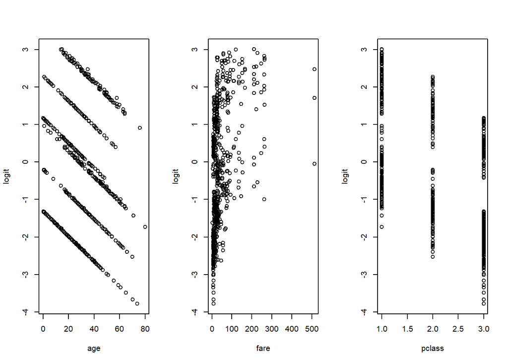

```r
titanic2 = titanic %>%
  mutate(probs = predict(main_effect_model, type = "response"),
         logit = log(probs / (1 - probs)))

# check for linearity of logit vs. quantitative predictors
par(mfrow = c(1, 3))
plot(logit ~ age, data = titanic2)
plot(logit ~ fare, data = titanic2)
plot(logit ~ pclass, data = titanic2)
```

# 1e.

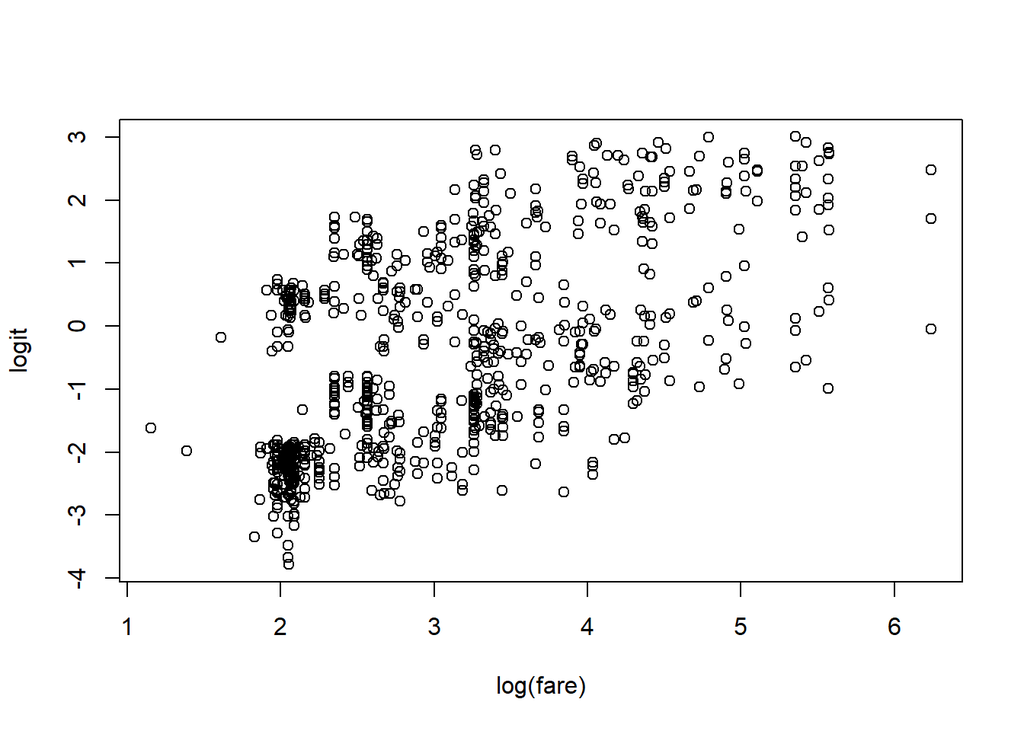

```r
plot(logit ~ log(fare), data = titanic2)
```

```r
main_effect_model2 = glm(survived ~ age + log(fare) + pclass + sex, family = binomial,data = titanic)
```

#1f

```r
#stepwise selection (because we have a qualitative variable with more than 2 categories)
intercept_only = glm(survived ~ 1, family = binomial, data = titanic)
step(intercept_only, formula(main_effect_model2))
```

```
## Start:  AIC=1064.78
## survived ~ 1
##
##             Df Deviance     AIC
## + sex        1   831.19  835.19
## + pclass     1   978.78  982.78
## + log(fare)  1   982.52  986.52
## <none>          1062.78 1064.78
## + age        1  1061.01 1065.01
##
## Step:  AIC=835.19
## survived ~ sex
##
##             Df Deviance     AIC
## + pclass     1   763.86  769.86
## + log(fare)  1   790.73  796.73
## <none>           831.19  835.19
## + age        1   830.30  836.30
## - sex        1  1062.78 1064.78
##
## Step:  AIC=769.86
## survived ~ sex + pclass
##
##             Df Deviance    AIC
## + age        1   740.04 748.04
## <none>           763.86 769.86
## + log(fare)  1   763.84 771.84
## - pclass     1   831.19 835.19
## - sex        1   978.78 982.78
##
## Step:  AIC=748.04
## survived ~ sex + pclass + age
##
##             Df Deviance    AIC
## <none>           740.04 748.04
## + log(fare)  1   739.28 749.28
## - age        1   763.86 769.86
## - pclass     1   830.30 836.30
## - sex        1   946.13 952.13
```

```
##
## Call:  glm(formula = survived ~ sex + pclass + age, family = binomial,
##     data = titanic)
##
## Coefficients:
## (Intercept)      sexmale       pclass          age
##     4.59498     -2.49347     -1.13876     -0.03352
##
## Degrees of Freedom: 784 Total (i.e. Null);  781 Residual
## Null Deviance:       1063
## Residual Deviance: 740   AIC: 748
```

```r
#stepwise removed log(fare) from the model.

#best subsets
survived_subs = regsubsets(survived ~ pclass + age + log(fare) + sex, data = titanic, nvmax = 10)
summary(survived_subs)
```

```
## Subset selection object
## Call: regsubsets.formula(survived ~ pclass + age + log(fare) + sex,
##     data = titanic, nvmax = 10)
## 4 Variables  (and intercept)
##           Forced in Forced out
## pclass        FALSE      FALSE
## age           FALSE      FALSE
## log(fare)     FALSE      FALSE
## sexmale       FALSE      FALSE
## 1 subsets of each size up to 4
## Selection Algorithm: exhaustive
##          pclass age log(fare) sexmale
## 1  ( 1 ) " "    " " " "       "*"
## 2  ( 1 ) "*"    " " " "       "*"
## 3  ( 1 ) "*"    "*" " "       "*"
## 4  ( 1 ) "*"    "*" "*"       "*"
```

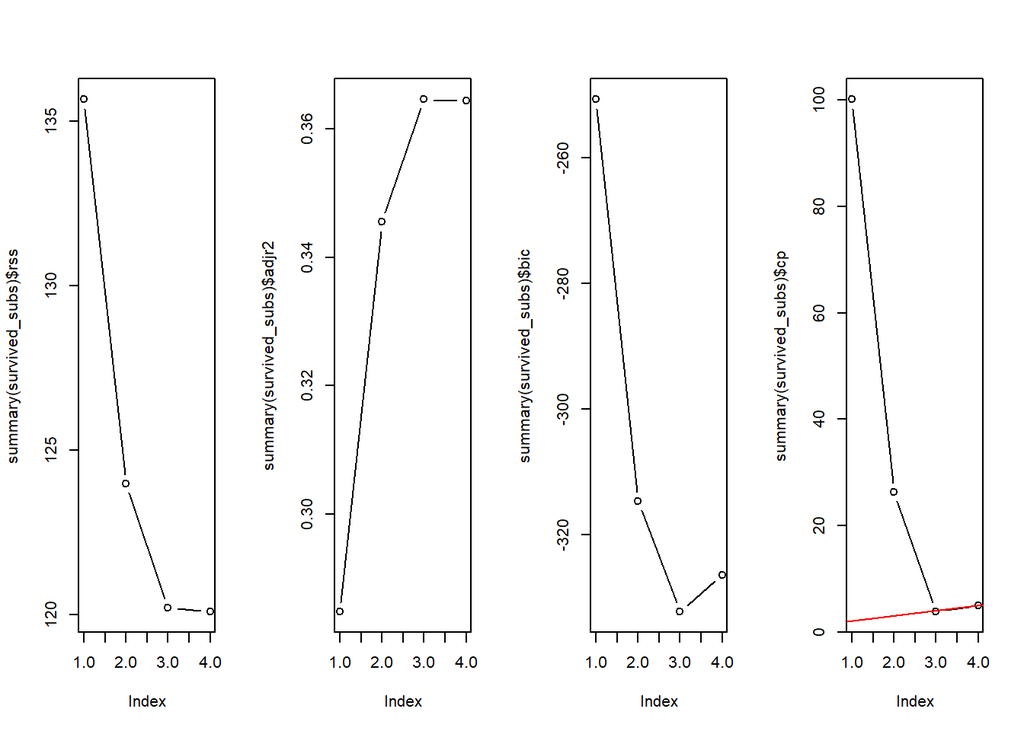

```r
par(mfrow = c(1, 4))
plot(summary(survived_subs)$rss, type = "b")
plot(summary(survived_subs)$adjr2, type = "b")
plot(summary(survived_subs)$bic, type = "b")
plot(summary(survived_subs)$cp, type = "b")
abline(1, 1, col = "red")
```

```r
#according to regsubsets 3 variable model is the best; remove log(fare) from the model.

main_effect_model3 = glm(survived ~ age + pclass + sex, family = binomial,data = titanic)
summary(main_effect_model3)
```

```
##
## Call:
## glm(formula = survived ~ age + pclass + sex, family = binomial,
##     data = titanic)
##
## Deviance Residuals:
##     Min       1Q   Median       3Q      Max
## -2.3189  -0.7103  -0.4260   0.6703   2.4004
##
## Coefficients:
##              Estimate Std. Error z value Pr(>|z|)
## (Intercept)  4.594980   0.460998   9.967  < 2e-16 ***
## age         -0.033520   0.007064  -4.746 2.08e-06 ***
## pclass      -1.138762   0.128309  -8.875  < 2e-16 ***
## sexmale     -2.493467   0.191064 -13.050  < 2e-16 ***
## ---
## Signif. codes:  0 '***' 0.001 '**' 0.01 '*' 0.05 '.' 0.1 ' ' 1
##
## (Dispersion parameter for binomial family taken to be 1)
##
##     Null deviance: 1062.78  on 784  degrees of freedom
## Residual deviance:  740.04  on 781  degrees of freedom
## AIC: 748.04
##
## Number of Fisher Scoring iterations: 4
```

#1g

```r
#significant interactions

model = glm(survived ~ age + pclass + sex + age * pclass, family = binomial,data = titanic)
summary(model) # not significant
```

```
##
## Call:
## glm(formula = survived ~ age + pclass + sex + age * pclass, family = binomial,
##     data = titanic)
##
## Deviance Residuals:
##     Min       1Q   Median       3Q      Max
## -2.3213  -0.7111  -0.4267   0.6693   2.3962
##
## Coefficients:
##               Estimate Std. Error z value Pr(>|z|)
## (Intercept)  4.6289913  0.7048660   6.567 5.13e-11 ***
## age         -0.0345224  0.0172189  -2.005    0.045 *
## pclass      -1.1544125  0.2767597  -4.171 3.03e-05 ***
## sexmale     -2.4940237  0.1912566 -13.040  < 2e-16 ***
## age:pclass   0.0005122  0.0080215   0.064    0.949
## ---
## Signif. codes:  0 '***' 0.001 '**' 0.01 '*' 0.05 '.' 0.1 ' ' 1
##
## (Dispersion parameter for binomial family taken to be 1)
##
##     Null deviance: 1062.78  on 784  degrees of freedom
## Residual deviance:  740.03  on 780  degrees of freedom
## AIC: 750.03
##
## Number of Fisher Scoring iterations: 4
```

```r
model2 = glm(survived ~ age + pclass + sex + age * sex, family = binomial,data = titanic)
summary(model2) # significant
```

```
##
## Call:
## glm(formula = survived ~ age + pclass + sex + age * sex, family = binomial,
##     data = titanic)
##
## Deviance Residuals:
##     Min       1Q   Median       3Q      Max
## -2.2901  -0.6893  -0.3981   0.6631   2.5293
##
## Coefficients:
##              Estimate Std. Error z value Pr(>|z|)
## (Intercept)  3.793280   0.502650   7.547 4.47e-14 ***
## age         -0.004087   0.010800  -0.378 0.705087
## pclass      -1.144163   0.130923  -8.739  < 2e-16 ***
## sexmale     -1.105758   0.408248  -2.709 0.006758 **
## age:sexmale -0.049514   0.013468  -3.677 0.000236 ***
## ---
## Signif. codes:  0 '***' 0.001 '**' 0.01 '*' 0.05 '.' 0.1 ' ' 1
##
## (Dispersion parameter for binomial family taken to be 1)
##
##     Null deviance: 1062.78  on 784  degrees of freedom
## Residual deviance:  725.81  on 780  degrees of freedom
## AIC: 735.81
##
## Number of Fisher Scoring iterations: 5
```

```r
model3 = glm(survived ~ age + pclass + sex + sex * pclass, family = binomial,data = titanic)
summary(model3) # most significant interaction
```

```
##
## Call:
## glm(formula = survived ~ age + pclass + sex + sex * pclass, family = binomial,
##     data = titanic)
##
## Deviance Residuals:
##     Min       1Q   Median       3Q      Max
## -2.9320  -0.7087  -0.4921   0.5028   2.2695
##
## Coefficients:
##                 Estimate Std. Error z value Pr(>|z|)
## (Intercept)     7.457361   0.837794   8.901  < 2e-16 ***
## age            -0.037187   0.007427  -5.007 5.52e-07 ***
## pclass         -2.243013   0.282532  -7.939 2.04e-15 ***
## sexmale        -6.113874   0.801520  -7.628 2.39e-14 ***
## pclass:sexmale  1.520921   0.304885   4.989 6.08e-07 ***
## ---
## Signif. codes:  0 '***' 0.001 '**' 0.01 '*' 0.05 '.' 0.1 ' ' 1
##
## (Dispersion parameter for binomial family taken to be 1)
##
##     Null deviance: 1062.78  on 784  degrees of freedom
## Residual deviance:  708.56  on 780  degrees of freedom
## AIC: 718.56
##
## Number of Fisher Scoring iterations: 5
```

```r
model4 = glm(survived ~ age + pclass + sex + age * sex + sex * pclass, family = binomial,data = titanic)
summary(model4) #age:sex not significant when included with sex:pclass
```

```
##
## Call:
## glm(formula = survived ~ age + pclass + sex + age * sex + sex *
##     pclass, family = binomial, data = titanic)
##
## Deviance Residuals:
##     Min       1Q   Median       3Q      Max
## -2.8494  -0.7041  -0.4756   0.5233   2.3300
##
## Coefficients:
##                Estimate Std. Error z value Pr(>|z|)
## (Intercept)     6.73107    0.98449   6.837 8.08e-12 ***
## age            -0.02358    0.01294  -1.822   0.0684 .
## pclass         -2.09945    0.29734  -7.061 1.66e-12 ***
## sexmale        -5.11300    1.10587  -4.623 3.77e-06 ***
## age:sexmale    -0.02007    0.01586  -1.266   0.2057
## pclass:sexmale  1.33281    0.33442   3.985 6.74e-05 ***
## ---
## Signif. codes:  0 '***' 0.001 '**' 0.01 '*' 0.05 '.' 0.1 ' ' 1
##
## (Dispersion parameter for binomial family taken to be 1)
##
##     Null deviance: 1062.78  on 784  degrees of freedom
## Residual deviance:  706.97  on 779  degrees of freedom
## AIC: 718.97
##
## Number of Fisher Scoring iterations: 5
```

```r
final_model = glm(survived ~ age + pclass + sex + sex * pclass, family = binomial,data = titanic)
```

#1h

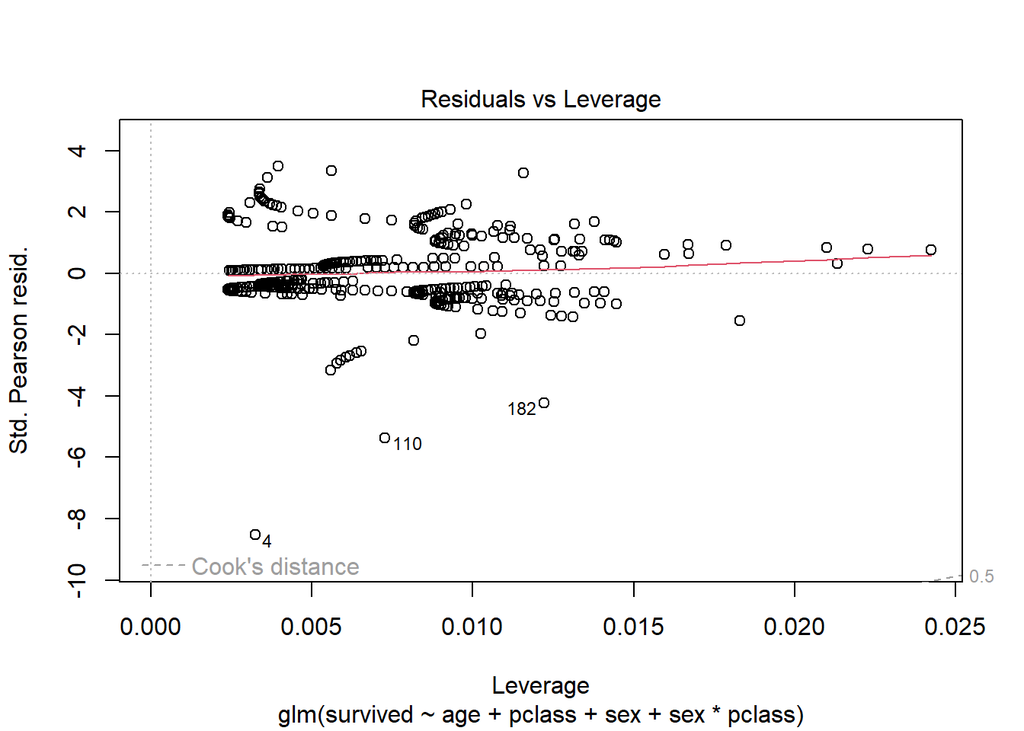

```r
# check influential points
plot(final_model, which = 5) #no influential points
```

#1i

```r
#probability
predict(final_model, newdata = data.frame(age = mean(titanic$age), sex = 'male', pclass = c(1:3)), type = "response")
```

```
##         1         2         3
## 0.3801272 0.2295064 0.1263976
```

```r
predict(final_model, newdata = data.frame(age = mean(titanic$age), sex = 'female', pclass = c(1:3)), type = "response")
```

```
##         1         2         3
## 0.9837606 0.8654054 0.4056248
```

According to the data output for the probability of males in each of the passenger classes who are of average age, there is a 38% chance of survival for men in first class, 23% chance of survival for men in second class, and 13% chance of survival for men in third class.

According to the data output for the probability of females in each of the passenger classes who are of average age, there is a 98% chance of survival for women in first class, 87% chance of survival in second class, and 41% chance of survival in third class.

#2a

Poisson regression is more appropriate than least squares regression for modeling monthly bank failures because it is able to count the discrete data of bank failures which are small occurrences in fixed amount of times (months).

#2b

```r
banks_model = glm(Failures ~ AdjTA, family = poisson, data = banks)
summary(banks_model)
```

```
##
## Call:
## glm(formula = Failures ~ AdjTA, family = poisson, data = banks)
##
## Deviance Residuals:
##     Min       1Q   Median       3Q      Max
## -1.9311  -1.0579  -0.3115   0.6105   1.5057
##
## Coefficients:
##               Estimate Std. Error z value Pr(>|z|)
## (Intercept) 13.7048842  4.3190668   3.173  0.00151 **
## AdjTA       -0.0009216  0.0002885  -3.195  0.00140 **
## ---
## Signif. codes:  0 '***' 0.001 '**' 0.01 '*' 0.05 '.' 0.1 ' ' 1
##
## (Dispersion parameter for poisson family taken to be 1)
##
##     Null deviance: 58.152  on 47  degrees of freedom
## Residual deviance: 48.565  on 46  degrees of freedom
## AIC: 110.45
##
## Number of Fisher Scoring iterations: 5
```

#2c

```r
1 - pchisq(banks_model$deviance, banks_model$df.residual)
```

```
## [1] 0.3699818
```

#2d

```r
exp(banks_model$coefficients)
```

```
##  (Intercept)        AdjTA
## 8.952732e+05 9.990788e-01
```

#2e

```r
stats::predict(banks_model, newdata = data.frame(AdjTA = 15000.00), type = "response")
```

```
##         1
## 0.8871576
```

There would be 0.8871576 bank failures during a month with adjusted total assets of $15,000 billion.